# Chicago Crime Data Description

Michael Arango

4/13/2017

# Getting Started

## Loading Libraries

```r
# load libraries
library(tidyverse)
library(lubridate)
```

## Importing Data

```r
df <- read_csv("/Users/michaelarango/Documents/ChicagoCrimeDataWarehouse/Data/Chicago_Crimes_2012_to_2017.csv")
glimpse(df)
```

```
## Observations: 1,456,714
## Variables: 23
## $ X1                   <int> 3, 89, 197, 673, 911, 1108, 1130, 1801, 1...
## $ ID                   <int> 10508693, 10508695, 10508697, 10508698, 1...
## $ Case Number          <chr> "HZ250496", "HZ250409", "HZ250503", "HZ25...
## $ Date                 <chr> "05/03/2016 11:40:00 PM", "05/03/2016 09:...
## $ Block                <chr> "013XX S SAWYER AVE", "061XX S DREXEL AVE...
## $ IUCR                 <chr> "0486", "0486", "0470", "0460", "0820", "...
## $ Primary Type         <chr> "BATTERY", "BATTERY", "PUBLIC PEACE VIOLA...
## $ Description          <chr> "DOMESTIC BATTERY SIMPLE", "DOMESTIC BATT...
## $ Location Description <chr> "APARTMENT", "RESIDENCE", "STREET", "SIDE...
## $ Arrest               <chr> "True", "False", "False", "False", "False...
## $ Domestic             <chr> "True", "True", "False", "False", "True",...
## $ Beat                 <int> 1022, 313, 1524, 1532, 1523, 631, 133, 21...
## $ District             <dbl> 10, 3, 15, 15, 15, 6, 1, 2, 24, 7, 3, 18,...
## $ Ward                 <dbl> 24, 20, 37, 28, 28, 8, 3, 3, 40, 17, 7, 4...
## $ Community Area       <dbl> 29, 42, 25, 25, 25, 44, 35, 38, 1, 67, 43...
## $ FBI Code             <chr> "08B", "08B", "24", "08B", "06", "04B", "...
## $ X Coordinate         <dbl> 1154907, 1183066, 1140789, 1143223, 11398...
## $ Y Coordinate         <dbl> 1893681, 1864330, 1904819, 1901475, 19016...
## $ Year                 <int> 2016, 2016, 2016, 2016, 2016, 2016, 2016,...
## $ Updated On           <chr> "05/10/2016 03:56:50 PM", "05/10/2016 03:...
## $ Latitude             <dbl> 41.86407, 41.78292, 41.89491, 41.88569, 4...
## $ Longitude            <dbl> -87.70682, -87.60436, -87.75837, -87.7495...
## $ Location             <chr> "(41.864073157, -87.706818608)", "(41.782...
```

The orginial dataset has 1456714 observations and 23 variables. The grain is an individual crime reported to the Chicago Police Department between 2012 and 2017.[^1] Since our free ETL tool (Talend Data Integration) cannot handle nearly this many observations, we need to remove some observations. We start by removing all observations prior to 2016 and all 2017 observations as this is a partial year.

# Slimming Down the Data

## Filtering Data by Year

```r
table(df$Year)
```

```
##
##   2012   2013   2014   2015   2016   2017
## 335670 306703 274527 262995 265462  11357
```

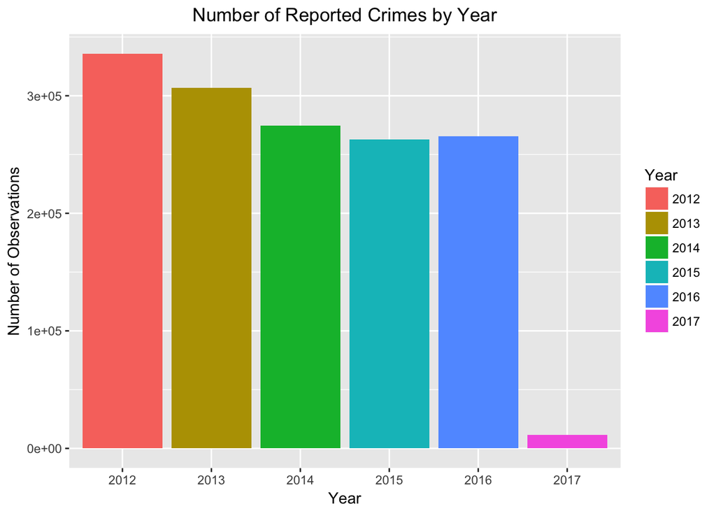

```r
ggplot(data = df) + geom_bar(aes(x = as.factor(Year), fill = as.factor(Year))) +
  labs(x = "Year", y = "Number of Observations", title = "Number of Reported Crimes by Year",
       fill = "Year") + theme(plot.title = element_text(hjust = 0.5))
```

```r
df <- df %>%
  filter(Year == 2016)
```

As we can see from the graph, the number of crimes reported in Chicago dropped pretty substantially from 2012 to 2015 and then rose slightly in 2016. By dropping all crimes from our dataset reported before or after 2016, we reduce the number of observations from 1456714 to 265462. We still need to get rid of a decent amount of observations from our dataset in order to use our ETL tools. The next way we should go about slimming down our data is by checking for missing data and whether or not we can drop it.

## Checking for Missing Data

```r
# Are there any missing values in the data?
any(is.na(df))
```

```
## [1] TRUE
```

```r
# Yes, but how many are there?
sum(is.na(df))
```

```
## [1] 71728
```

```r
# There are 71,728 missing observations***
# return index of columns that have missing values
na.cols = which(colSums(is.na(df)) > 0)
# Break down missing values by variable
sort(colSums(sapply(df[na.cols], is.na)), decreasing = TRUE)
```

```
##         X Coordinate         Y Coordinate             Latitude
##                14189                14189                14189
##            Longitude             Location Location Description
##                14189                14189                  783
```

Of the 265462 rows, there are 71728 missing values. The output above shows the columns in the dataset that are missing values and the number of missing values. We feel comfortable dropping all values missing data in the location dimension for this project—even if it adds a small amount of bias to our results.

## Dropping Missing Data

```r
# drop all rows missing data in the X Coordinate column
df <- df %>%
  filter(!is.na(`X Coordinate`))
# Check which columns still have missing data and how many
na.cols = which(colSums(is.na(df)) > 0)
sort(colSums(sapply(df[na.cols], is.na)), decreasing = TRUE)
```

```
## Location Description
##                  541
```

Luckily, all observations missing `X Coordinate` information were the same ones missing data for `Y Coordinate`, `Latitude`, `Longitude`, and `Location`.[^2] By dropping these observations, we only got rid of 1.418910^{4} observations (5.35% of all reported crimes in Chicago in 2016). We are going to go ahead and drop the 541 rows that have missing data in the `Location Description` column.

```r
# drop all rows missing data in the Location Description column
df <- df %>%
  filter(!is.na(`Location Description`))
# Are there any more NA values?
any(is.na(df))
```

```
## [1] FALSE
```

After dropping all rows with missing `Location Description` data, we have 250732 observations left (94.45% of all reported crimes in Chicago in 2016).

## Dropping Extraneous Columns

There are a few columns that we decided to drop because they don’t necessarily fit into a dimension in our dimensional model for the data warehouse—`IUCR`, `ID`, and `FBI`. Additionally, when we imported the data from the csv, we saw there was an arbitrary row index `X1` that could also be dropped.

```r
# specified dplyr::select because several data analysis packages mask the dplyr select command
df <- dplyr::select(df, -X1, -ID, -IUCR, -`FBI Code`)
```

We are left with 250732 observations of 19 variables. In order to figure out a method for reducing the size of the dataset, we should look at the distribution of reported crimes in 2016 by month.

## Changing Date to Information We Can Use

```r
# drop the original Year column
df$Year <- NULL
# split Date into Date and Time
df <- df %>%
  separate(col = Date, into = c("Date", "Time"), sep = " ", extra = "merge")
# save as date variable
df$Date <- mdy(df$Date)
# split date into month, day, year
df <- df %>%
  separate(col = Date, into = c("Year", "Month", "Day"), sep = "-")
# split time into hours, minutes, seconds
df <- df %>%
  separate(col = Time, into = c("Hour", "Minute", "Second"), sep = ":")
# split second
df <- df %>%
  separate(col = Second, into = c("Second", "AM.PM"), sep = " ")
# drop second
df$Second <- NULL
df$Hour <- as.integer(df$Hour)
# Convert to 24 hour time
index <- which(df$AM.PM == "PM")
df[index, 'Hour'] <- df[index, 'Hour'] + 12
# drop AM.PM
df$AM.PM <- NULL
# change
cols <- c(2:6)
df[, cols] <- lapply(df[, cols], as.integer)
df <- df %>%
  mutate(`Report Time` = make_datetime(Year, Month, Day, Hour, Minute))
df$Weekday <- wday(df$`Report Time`, label = TRUE, abbr = FALSE)
df$`Report Time` <- df$`Updated On` <- NULL
```

## Plotting Reported Crimes by Month

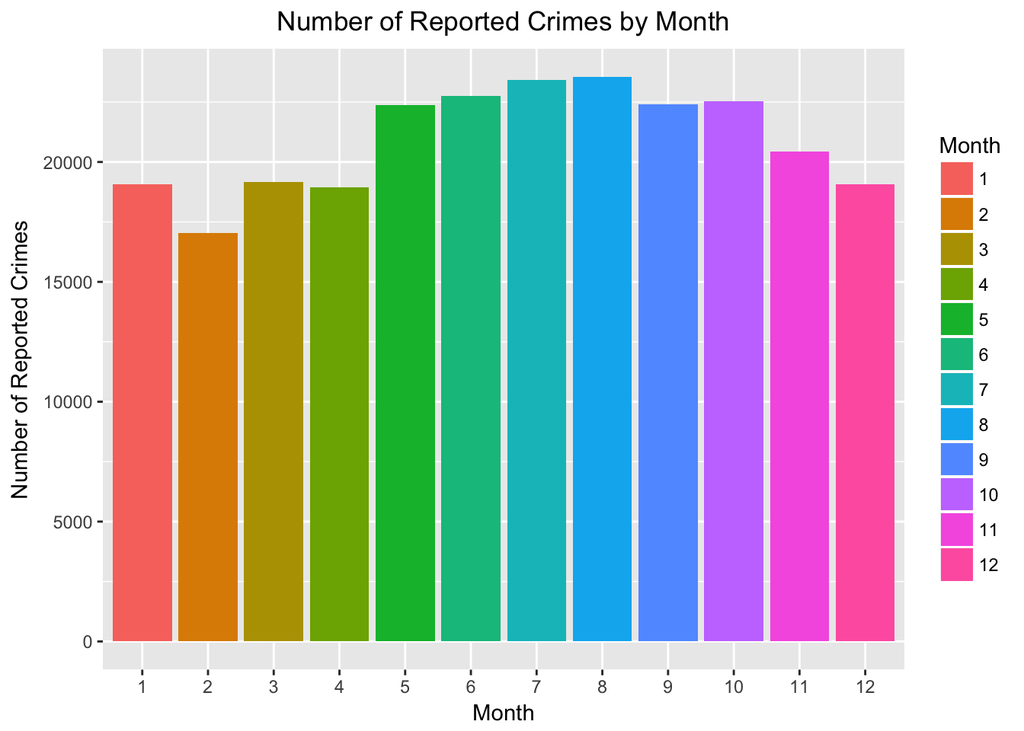

```r
ggplot(df) + geom_bar(aes(x = as.factor(Month), fill = as.factor(Month))) + labs(x = "Month", y = "Number of Reported Crimes", title = "Number of Reported Crimes by Month",
       fill = "Month") + theme(plot.title = element_text(hjust = 0.5))
```

## Randomly Sampling to Subset for Data Warehouse

```r
# set seed for reproducibility
set.seed(256)
# take a random sample of n = 30,000 without replacement
df <- df[sample(1:nrow(df), 30000, replace = FALSE), ]
```

## Examining the Sample Data

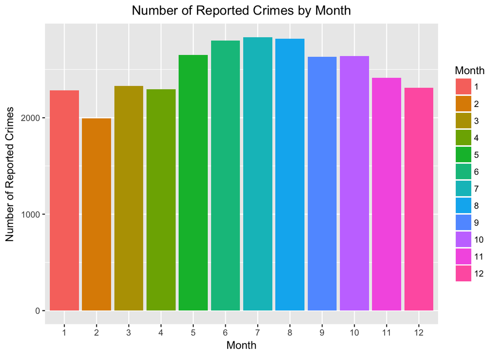

```r
ggplot(df) + geom_bar(aes(x = as.factor(Month), fill = as.factor(Month))) + labs(x = "Month", y = "Number of Reported Crimes", title = "Number of Reported Crimes by Month",
       fill = "Month") + theme(plot.title = element_text(hjust = 0.5))
```

The sample has roughly the same shape as the whole year. This is exactly what we wanted.

# Write Sample Data to .csv

```r
write_csv(df, "/Users/michaelarango/Documents/ChicagoCrimeDataWarehouse/Data/ChicagoSample.csv")
```

# Footnotes

[^1]: Note that since we are only in the fourth month of 2017 this will not be a complete year of crime observations.
[^2]: There were also 242 `Location Description` missing values that were remedied by dropping the observations with no `X Coordinate` information.